# RM-ANOVA for coevolution with a seed bank

## Population density data

I have previously consolidated all the data on population density collected for this experiment. This includes:

| Population | What it is | Method of measurement |
| --- | --- | --- |
| spore / mL | host spore density | flow-cytometry: low SYBR population |
| veg / mL | host vegetative cell density | flow-cytometry: high SYBR population |
| cell /mL | total host cell density (spore+veg) | flow-cytometry |
| phage/ mL | total SPO1 phage density (free phage) | qPCR (SYBR) with phage specific primers and lysate serial dilution as standard |

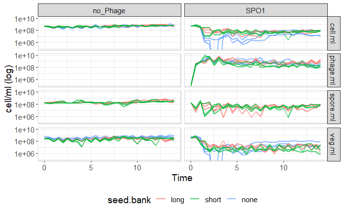

Notably, in the first few days of the experiment cell numbers dropped below detection limit in 2 of 3 SNO lines. Missing data cannot be analyzed in RM-ANOVA. So for cell data let’s look at data from day 4 and onward:

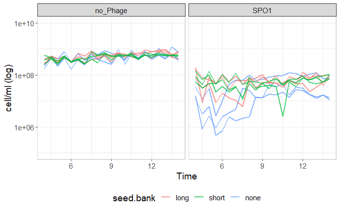

```r
d <- d%>%
  filter(Time>=4)

# plot total cells of raw data
d%>%
    ggplot(aes(x=Time, y=cell.ml))+
      geom_line(aes(group=flask,color=seed.bank), size=1, alpha=0.7)+
      facet_wrap(~phage)+
      theme_bw()+
      panel_border()+
      scale_y_log10()+
      theme(legend.position = "bottom",
            text=element_text(size=14))+
      ylab("cell/ml (log)")+
      coord_cartesian(ylim = c(1e5, 1e10))
```

## Model selection

### ARMA covariance

This is a combined auto-regeressive model, AR(p) and moving average model, MA(q). I here take a model selection approach to choose these parameters (lowest AIC).

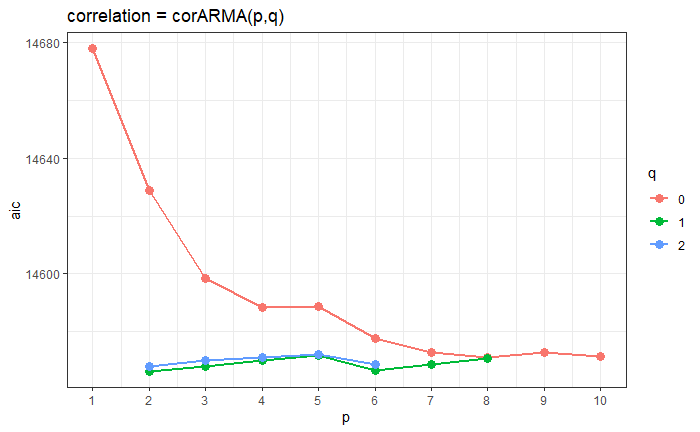

```r
# initalise empty table
pq.aic <- tibble(p=1, q=1,aic=1)%>%
  filter(p>1)

# Playing around with p&q I found the sappce in which the model conerges is limited
for(Q in c(0:2)){
  for (P in c(1:(10-2*Q))){

    #this fllowing combination does not work: "Coefficient matrix not invertible"
    if(P==1 & Q==1) next
    if(P==1 & Q==2) next

    cur.model <-
        d%>%
  # looking only at total cells (cell.ml)
    lme(cell.ml ~ phage * seed.bank * Time , random = ~1|flask,
            correlation = corARMA(form = ~ 1 | flask, p=P,q=Q),
            data = .)

    pq.aic <-
      tibble(p=P, q=Q,aic=AIC(cur.model))%>%
      bind_rows(pq.aic,.)

  }
}

pq.aic%>%
  mutate(q=as.character(q))%>%
  ggplot(aes(p,aic))+
  geom_line(aes(color=q),size=1)+
  geom_point(aes(color=q),size=3)+
  theme_bw()+
  scale_x_continuous(breaks = 1:10)+
  ggtitle("correlation = corARMA(p,q)")
```

```r
NA
NA
```

There are 4 models with lowest AIC, those having p=2 or p=6, and withe q=1 or q=2. Over all the q=1 models seem to be doin better.

### compare AR1 with ARMA

```r
# corAR1
cell.rm.AR1 <-
  d%>%
  # looking only at total cells (cell.ml)
    lme(cell.ml ~ phage * seed.bank * Time , random = ~1|flask,
            correlation = corAR1(form = ~ 1 | flask),
            data = .)

# corARMA models
cell.rm.ARMA.p2q1 <-
        d%>%
  # looking only at total cells (cell.ml)
    lme(cell.ml ~ phage * seed.bank * Time , random = ~1|flask,
            correlation = corARMA(form = ~ 1 | flask, p=2,q=1),
            data = .)

cell.rm.ARMA.p2q2 <-
        d%>%
  # looking only at total cells (cell.ml)
    lme(cell.ml ~ phage * seed.bank * Time , random = ~1|flask,
            correlation = corARMA(form = ~ 1 | flask, p=2,q=2),
            data = .)

cell.rm.ARMA.p6q1 <-
        d%>%
  # looking only at total cells (cell.ml)
    lme(cell.ml ~ phage * seed.bank * Time , random = ~1|flask,
            correlation = corARMA(form = ~ 1 | flask, p=6,q=1),
            data = .)

cell.rm.ARMA.p6q2 <-
        d%>%
  # looking only at total cells (cell.ml)
    lme(cell.ml ~ phage * seed.bank * Time , random = ~1|flask,
            correlation = corARMA(form = ~ 1 | flask, p=6,q=2),
            data = .)

AIC(cell.rm.AR1,cell.rm.ARMA.p2q1,cell.rm.ARMA.p2q2,cell.rm.ARMA.p6q1,cell.rm.ARMA.p6q2)%>%
  arrange(AIC)
```

|  | df | AIC |
| --- | --- | --- |
| cell.rm.ARMA.p2q1 | 17 | 14566.31 |
| cell.rm.ARMA.p6q1 | 21 | 14566.76 |
| cell.rm.ARMA.p2q2 | 18 | 14568.03 |
| cell.rm.ARMA.p6q2 | 22 | 14568.65 |
| cell.rm.AR1 | 15 | 14677.85 |

The model ARMA p2q1 model is the best.

Is the improvment significant?

|  | Model | df | AIC | BIC | logLik | Test | L.Ratio | p-value |
| --- | --- | --- | --- | --- | --- | --- | --- | --- |
| cell.rm.AR1 | 1 | 15 | 14677.84 | 14736.39 | -7323.923 |  |  |  |
| cell.rm.ARMA.p6q2 | 2 | 22 | 14568.65 | 14654.50 | -7262.323 | 1 vs 2 | 123.19843 | <.0001 |
| cell.rm.ARMA.p2q2 | 3 | 18 | 14568.03 | 14638.28 | -7266.015 | 2 vs 3 | 7.38355 | 0.1170 |
| cell.rm.ARMA.p6q1 | 4 | 21 | 14566.76 | 14648.71 | -7262.379 | 3 vs 4 | 7.27215 | 0.0637 |
| cell.rm.ARMA.p2q1 | 5 | 17 | 14566.31 | 14632.65 | -7266.153 | 4 vs 5 | 7.54818 | 0.1096 |

Selecting the ARMA model woth smaller degrees of freedom: p2q1.

### ARMA.p2q1

```r
car::Anova(cell.rm.ARMA.p2q1)
```

```
Analysis of Deviance Table (Type II tests)

Response: cell.ml
                        Chisq Df Pr(>Chisq)
phage                766.5762  1  < 2.2e-16 ***
seed.bank              4.7277  2    0.09406 .
Time                  63.4271  1  1.664e-15 ***
phage:seed.bank        1.3264  2    0.51519
phage:Time            49.9280  1  1.595e-12 ***
seed.bank:Time         2.0315  2    0.36213
phage:seed.bank:Time   2.4367  2    0.29572
---
Signif. codes:  0 ‘***’ 0.001 ‘**’ 0.01 ‘*’ 0.05 ‘.’ 0.1 ‘ ’ 1
```

Hoe sensetive would the result be to model selected?

```r
car::Anova(cell.rm.ARMA.p6q2)
```

```
Analysis of Deviance Table (Type II tests)

Response: cell.ml
                        Chisq Df Pr(>Chisq)
phage                768.2607  1  < 2.2e-16 ***
seed.bank              4.9660  2    0.08349 .
Time                  55.5610  1  9.060e-14 ***
phage:seed.bank        1.3494  2    0.50930
phage:Time            43.8875  1  3.478e-11 ***
seed.bank:Time         1.8615  2    0.39425
phage:seed.bank:Time   2.2303  2    0.32786
---
Signif. codes:  0 ‘***’ 0.001 ‘**’ 0.01 ‘*’ 0.05 ‘.’ 0.1 ‘ ’ 1
```

### ARMA.p2q2

```r
car::Anova(cell.rm.ARMA.p2q2)
```

```
Analysis of Deviance Table (Type II tests)

Response: cell.ml
                        Chisq Df Pr(>Chisq)
phage                772.0178  1  < 2.2e-16 ***
seed.bank              4.7831  2    0.09149 .
Time                  67.3763  1  2.243e-16 ***
phage:seed.bank        1.3597  2    0.50670
phage:Time            52.7674  1  3.755e-13 ***
seed.bank:Time         2.1641  2    0.33889
phage:seed.bank:Time   2.6043  2    0.27194
---
Signif. codes:  0 ‘***’ 0.001 ‘**’ 0.01 ‘*’ 0.05 ‘.’ 0.1 ‘ ’ 1
```

### ARMA.p6q2

```r
car::Anova(cell.rm.ARMA.p6q2)
```

```
Analysis of Deviance Table (Type II tests)

Response: cell.ml
                        Chisq Df Pr(>Chisq)
phage                768.2607  1  < 2.2e-16 ***
seed.bank              4.9660  2    0.08349 .
Time                  55.5610  1  9.060e-14 ***
phage:seed.bank        1.3494  2    0.50930
phage:Time            43.8875  1  3.478e-11 ***
seed.bank:Time         1.8615  2    0.39425
phage:seed.bank:Time   2.2303  2    0.32786
---
Signif. codes:  0 ‘***’ 0.001 ‘**’ 0.01 ‘*’ 0.05 ‘.’ 0.1 ‘ ’ 1
```

### AR1

```r
car::Anova(cell.rm.AR1)
```

```
Analysis of Deviance Table (Type II tests)

Response: cell.ml
                        Chisq Df Pr(>Chisq)
phage                821.5206  1    < 2e-16 ***
seed.bank              5.3034  2    0.07053 .
Time                 107.7717  1    < 2e-16 ***
phage:seed.bank        1.7095  2    0.42538
phage:Time            80.5798  1    < 2e-16 ***
seed.bank:Time         3.4317  2    0.17981
phage:seed.bank:Time   3.9133  2    0.14133
---
Signif. codes:  0 ‘***’ 0.001 ‘**’ 0.01 ‘*’ 0.05 ‘.’ 0.1 ‘ ’ 1
```

## Post hoc

comparing means across seed bank for phage treatments seperatly. First with phage:

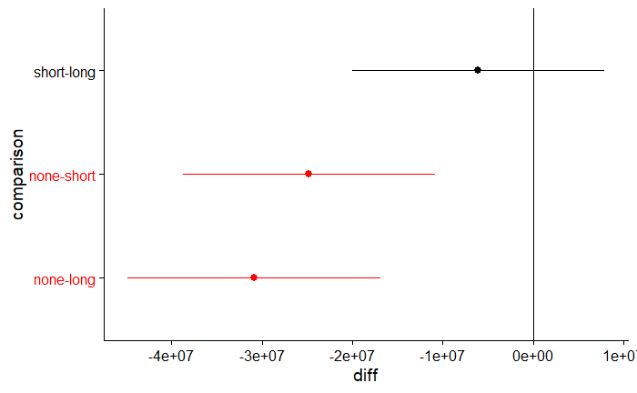

```r
# I wrote a function to nicely plot the results of this test
source(here("code","functions", "plot_TukeyHSD.R"))

tuk <- TukeyHSD(aov(cell.ml~seed.bank,data = filter(d, phage=="SPO1")))

plot_TukeyHSD(tuk)
```

Without phage:

[output not shown]

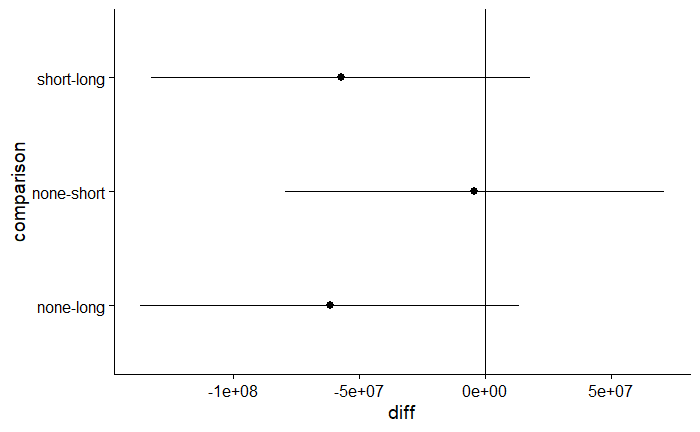

```r
tuk <- TukeyHSD(aov(cell.ml~seed.bank,data = filter(d, phage!="SPO1")))

plot_TukeyHSD(tuk)
```

The differences in cell density are only in phage treatment between no seed-bank and the other 2 seed-bank trearments.

# phage density

```r
d%>%
  filter(phage=="SPO1")%>%
    ggplot(aes(x=Time, y=phage.ml))+
      geom_line(aes(group=flask,color=seed.bank), size=1, alpha=0.7)+
      theme_bw()+
      panel_border()+
      scale_y_log10()+
      theme(legend.position = "bottom",
            text=element_text(size=14))+
      ylab("cell/ml (log)")+
      coord_cartesian(ylim = c(1e5, 1e10))
```

[output not shown]

## Model selection

### ARMA covariance

This is a combined auto-regeressive model, AR(p) and moving average model, MA(q). I here take a model selection approach to choose these parameters (lowest AIC).

```r
# initalise empty table
pq.aic <- tibble(p=1, q=1,aic=1)%>%
  filter(p>1)

# Playing around with p&q I found the sappce in which the model conerges is limited
for(Q in c(0:2)){
  for (P in c(1:(10-2*Q))){

    #this following combination does not work: "Citeration limit reached without convergence"
    if(P==4 & Q==1) next
    if(P==6 & Q==2) next
    #this following combination does not work: " Coefficient matrix not invertible"
    if(P==2 & Q==2) next

    cur.model <-
        d%>%
      filter(phage=="SPO1")%>%
  # looking only at total phage (phage.ml)
    lme(phage.ml ~ seed.bank * Time , random = ~1|flask,
            correlation = corARMA(form = ~ 1 | flask, p=P,q=Q),
            data = .)

    pq.aic <-
      tibble(p=P, q=Q,aic=AIC(cur.model))%>%
      bind_rows(pq.aic,.)

  }
}

pq.aic%>%
  mutate(q=as.character(q))%>%
  ggplot(aes(p,aic))+
  geom_line(aes(color=q),size=1)+
  geom_point(aes(color=q),size=3)+
  theme_bw()+
  scale_x_continuous(breaks = 1:10)+
  ggtitle("correlation = corARMA(p,q)")
```

[output not shown]

### compare AR1 with ARMA

```r
# corAR1
phage.rm.AR1 <-
  d%>%
        filter(phage=="SPO1")%>%
  # looking only at total phage (phage.ml)
    lme(phage.ml ~ seed.bank * Time , random = ~1|flask,
            correlation = corAR1(form = ~ 1 | flask),
            data = .)

# corARMA models
phage.rm.ARMA.p3q2 <-
        d%>%
       filter(phage=="SPO1")%>%
  # looking only at total phage (phage.ml)
    lme(phage.ml ~ seed.bank * Time , random = ~1|flask,
            correlation = corARMA(form = ~ 1 | flask, p=3,q=2),
            data = .)

phage.rm.ARMA.p4q2 <-
        d%>%
       filter(phage=="SPO1")%>%
  # looking only at total phage (phage.ml)
    lme(phage.ml ~ seed.bank * Time , random = ~1|flask,
            correlation = corARMA(form = ~ 1 | flask, p=4,q=2),
            data = .)

phage.rm.ARMA.p5q1 <-
        d%>%
       filter(phage=="SPO1")%>%
  # looking only at total phage (phage.ml)
    lme(phage.ml ~ seed.bank * Time , random = ~1|flask,
            correlation = corARMA(form = ~ 1 | flask, p=5,q=1),
            data = .)

phage.rm.ARMA.p6q1 <-
        d%>%
       filter(phage=="SPO1")%>%
  # looking only at total phage (phage.ml)
    lme(phage.ml ~ seed.bank * Time , random = ~1|flask,
            correlation = corARMA(form = ~ 1 | flask, p=6,q=1),
            data = .)

AIC(phage.rm.AR1,phage.rm.ARMA.p3q2,phage.rm.ARMA.p4q2,phage.rm.ARMA.p5q1,phage.rm.ARMA.p6q1)%>%
  arrange(AIC)
```

[output not shown]

Is the improvment significant?

```r
AIC(phage.rm.AR1,phage.rm.ARMA.p3q2,phage.rm.ARMA.p4q2,phage.rm.ARMA.p5q1,phage.rm.ARMA.p6q1)%>%
  arrange(desc(AIC))%>%
  row.names()

anova(phage.rm.AR1,phage.rm.ARMA.p6q1,phage.rm.ARMA.p3q2,phage.rm.ARMA.p5q1,phage.rm.ARMA.p4q2)
```

[output not shown]

Selecting the ARMA model woth smaller degrees of freedom: p3q2

### ARMA.p3q2

```r
car::Anova(phage.rm.ARMA.p3q2)
```

[output not shown]

How sensetive would the result be to model selected?

### ARMA.p4q2

```r
car::Anova(phage.rm.ARMA.p4q2)
```

[output not shown]

### ARMA.p5q1

```r
car::Anova(phage.rm.ARMA.p5q1)
```

[output not shown]

```r
car::Anova(phage.rm.ARMA.p6q1)
```

[output not shown]

### AR1

```r
car::Anova(phage.rm.AR1)
```

[output not shown]

## Post hoc

comparing means across seed bank:

```r
tuk <- TukeyHSD(aov(phage.ml~seed.bank,data = filter(d, phage=="SPO1")))

plot_TukeyHSD(tuk)
```

[output not shown]

# spore density

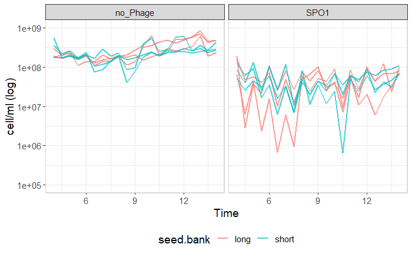

## Model selection

### ARMA covariance

This is a combined auto-regeressive model, AR(p) and moving average model, MA(q). I here take a model selection approach to choose these parameters (lowest AIC).

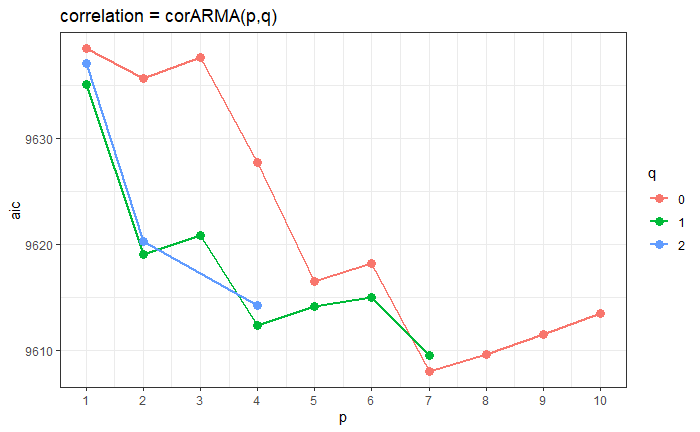

There are 2 models with lowest AIC, those having (p=7 ,q=0 ); (p=7 ,q=1 ).

### compare AR1 with ARMA

|  | df | AIC |
| --- | --- | --- |
| spore.rm.ARMA.p7q0 | 17 | 9608.078 |
| spore.rm.ARMA.p7q1 | 18 | 9609.595 |
| spore.rm.ARMA.p2q1 | 13 | 9619.061 |
| spore.rm.AR1 | 11 | 9638.456 |

|  | Model | df | AIC | BIC | logLik | Test | L.Ratio | p-value |
| --- | --- | --- | --- | --- | --- | --- | --- | --- |
| spore.rm.AR1 | 1 | 11 | 9638.456 | 9676.925 | -4808.228 |  |  |  |
| spore.rm.ARMA.p7q1 | 2 | 18 | 9609.595 | 9672.544 | -4786.797 | 1 vs 2 | 42.86139 | <.0001 |
| spore.rm.ARMA.p2q1 | 3 | 13 | 9619.061 | 9664.524 | -4796.530 | 2 vs 3 | 19.46593 | 0.0016 |
| spore.rm.ARMA.p7q0 | 4 | 17 | 9608.078 | 9667.530 | -4787.039 | 3 vs 4 | 18.98269 | 0.0008 |

ARMA models are signficantly better

```r
anova(spore.rm.ARMA.p7q0)
```

|  | numDF | denDF | F-value | p-value |
| --- | --- | --- | --- | --- |
| (Intercept) | 1 | 236 | 343.9832 | <.0001 |
| phage | 1 | 8 | 157.2433 | <.0001 |
| seed.bank | 1 | 8 | 2.4306 | 0.1576 |
| Time | 1 | 236 | 7.6559 | 0.0061 |
| phage:seed.bank | 1 | 8 | 1.7706 | 0.2200 |
| phage:Time | 1 | 236 | 9.7677 | 0.0020 |
| seed.bank:Time | 1 | 236 | 4.0550 | 0.0452 |
| phage:seed.bank:Time | 1 | 236 | 5.1113 | 0.0247 |

phage:seed.bank:Time is significant.

```r
anova(spore.rm.ARMA.p7q1)
```

|  | numDF | denDF | F-value | p-value |
| --- | --- | --- | --- | --- |
| (Intercept) | 1 | 236 | 391.5121 | <.0001 |
| phage | 1 | 8 | 178.9037 | <.0001 |
| seed.bank | 1 | 8 | 2.8469 | 0.1300 |
| Time | 1 | 236 | 7.4785 | 0.0067 |
| phage:seed.bank | 1 | 8 | 2.0678 | 0.1884 |
| phage:Time | 1 | 236 | 9.6615 | 0.0021 |
| seed.bank:Time | 1 | 236 | 4.2129 | 0.0412 |
| phage:seed.bank:Time | 1 | 236 | 5.2938 | 0.0223 |

|  | numDF | denDF | F-value | p-value |
| --- | --- | --- | --- | --- |
| (Intercept) | 1 | 236 | 268.02427 | <.0001 |
| phage | 1 | 8 | 122.55451 | <.0001 |
| seed.bank | 1 | 8 | 1.44929 | 0.2631 |
| Time | 1 | 236 | 11.03701 | 0.0010 |
| phage:seed.bank | 1 | 8 | 1.09405 | 0.3261 |
| phage:Time | 1 | 236 | 12.68008 | 0.0004 |
| seed.bank:Time | 1 | 236 | 3.69363 | 0.0558 |
| phage:seed.bank:Time | 1 | 236 | 4.58564 | 0.0333 |

```r
anova(spore.rm.AR1)
```

|  | numDF | denDF | F-value | p-value |
| --- | --- | --- | --- | --- |
| (Intercept) | 1 | 236 | 335.9156 | <.0001 |
| phage | 1 | 8 | 152.5596 | <.0001 |
| seed.bank | 1 | 8 | 2.0093 | 0.1941 |
| Time | 1 | 236 | 15.1107 | 0.0001 |
| phage:seed.bank | 1 | 8 | 1.6034 | 0.2410 |
| phage:Time | 1 | 236 | 16.5074 | 0.0001 |
| seed.bank:Time | 1 | 236 | 4.6280 | 0.0325 |
| phage:seed.bank:Time | 1 | 236 | 5.3154 | 0.0220 |

Significance of 3-way interaction holds in all models.

## Post hoc

comparing means across seed bank for phage treatments seperatly, forst with phage:

```r
tuk <- TukeyHSD(aov(spore.ml~seed.bank,data = filter(d,host=="WT" &phage=="SPO1")))
tuk
```

```
  Tukey multiple comparisons of means
    95% family-wise confidence level

Fit: aov(formula = spore.ml ~ seed.bank, data = filter(d, host == "WT" & phage == "SPO1"))

$seed.bank
                diff       lwr      upr     p adj
short-long -949905.9 -13300692 11400880 0.8792549
```

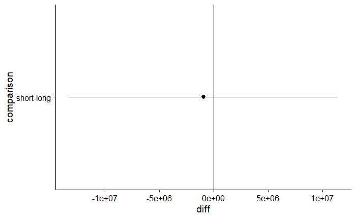

```r
plot_TukeyHSD(tuk)
```

And now wothout phage

```r
tuk <- TukeyHSD(aov(spore.ml~seed.bank,data = filter(d,host=="WT" &phage!="SPO1")))
tuk
```

```
  Tukey multiple comparisons of means
    95% family-wise confidence level

Fit: aov(formula = spore.ml ~ seed.bank, data = filter(d, host == "WT" & phage != "SPO1"))

$seed.bank
                diff        lwr      upr     p adj
short-long -52165596 -102795120 -1536072 0.0435421
```

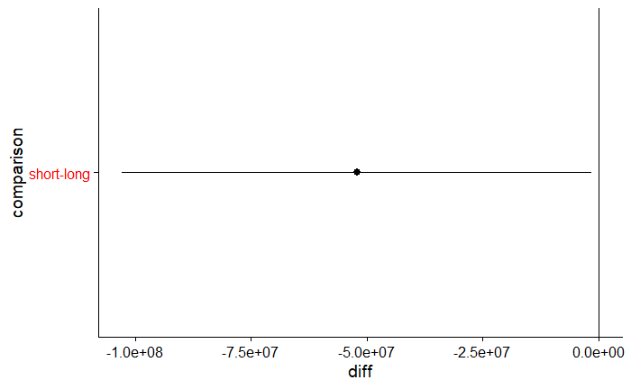

```r
plot_TukeyHSD(tuk)
```

```r
NA
NA
```

There is a seed-bank treatment effect only in the absence of phage. The effect seems very small (conf. interval on dofference almost at 0)

========================================= # spore percent

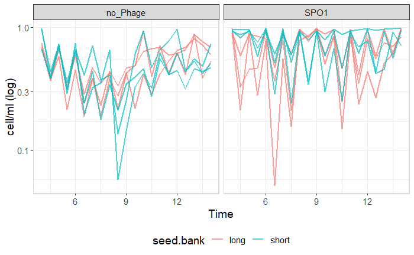

## Model selection

### ARMA covariance

This is a combined auto-regeressive model, AR(p) and moving average model, MA(q). I here take a model selection approach to choose these parameters (lowest AIC).

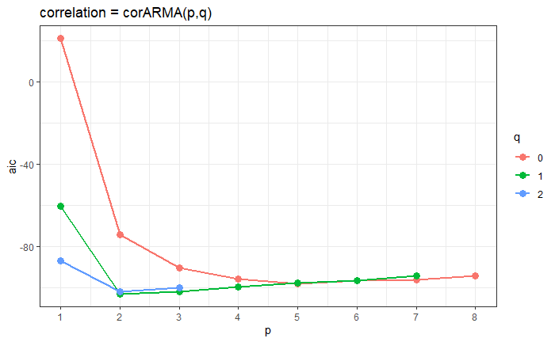

```r
# initalise empty table
pq.aic <- tibble(p=1, q=1,aic=1)%>%
  filter(p>1)

# Playing around with p&q I found the sappce in which the model conerges is limited
for(Q in c(0:2)){
  for (P in c(1:(10-2*Q))){

    # # #this following combination does not work: "Citeration limit reached without convergence"
    if(P>=9 & Q==0) next
    if(P>=8 & Q==1) next
    if(P>=4 & Q==2) next
    # if(P>=5 & Q==2) next

    cur.model <-
        d.perc%>%
  # looking only at total phage (phage.ml)
    lme(perc.spore ~ phage*seed.bank * Time , random = ~1|flask,
            correlation = corARMA(form = ~ 1 | flask, p=P,q=Q),
            data = .)

    pq.aic <-
      tibble(p=P, q=Q,aic=AIC(cur.model))%>%
      bind_rows(pq.aic,.)

  }
}

pq.aic%>%
  mutate(q=as.character(q))%>%
  ggplot(aes(p,aic))+
  geom_line(aes(color=q),size=1)+
  geom_point(aes(color=q),size=3)+
  theme_bw()+
  scale_x_continuous(breaks = 1:10)+
  ggtitle("correlation = corARMA(p,q)")
```

```r
NA
NA
```

### compare AR1 with ARMA

|  | df | AIC |
| --- | --- | --- |
| pspore.rm.ARMA.p2q2 | 14 | -101.74890 |
| pspore.rm.ARMA.p2q3 | 15 | -99.79761 |
| pspore.rm.AR1 | 11 | 20.93241 |

|  | Model | df | AIC | BIC | logLik | Test | L.Ratio | p-value |
| --- | --- | --- | --- | --- | --- | --- | --- | --- |
| pspore.rm.AR1 | 1 | 11 | 20.93241 | 59.40126 | 0.53380 |  |  |  |
| pspore.rm.ARMA.p2q3 | 2 | 15 | -99.79761 | -47.34009 | 64.89881 | 1 vs 2 | 128.73002 | <.0001 |
| pspore.rm.ARMA.p2q2 | 3 | 14 | -101.74890 | -52.78854 | 64.87445 | 2 vs 3 | 0.04871 | 0.8253 |

ARMA models are signficantly better

|  | numDF | denDF | F-value | p-value |
| --- | --- | --- | --- | --- |
| (Intercept) | 1 | 236 | 952.8358 | <.0001 |
| phage | 1 | 8 | 33.3177 | 0.0004 |
| seed.bank | 1 | 8 | 1.2236 | 0.3008 |
| Time | 1 | 236 | 0.2571 | 0.6126 |
| phage:seed.bank | 1 | 8 | 2.4546 | 0.1558 |
| phage:Time | 1 | 236 | 0.1112 | 0.7391 |
| seed.bank:Time | 1 | 236 | 2.1916 | 0.1401 |
| phage:seed.bank:Time | 1 | 236 | 0.3088 | 0.5790 |

|  | numDF | denDF | F-value | p-value |
| --- | --- | --- | --- | --- |
| (Intercept) | 1 | 236 | 971.3086 | <.0001 |
| phage | 1 | 8 | 34.0466 | 0.0004 |
| seed.bank | 1 | 8 | 1.2490 | 0.2962 |
| Time | 1 | 236 | 0.2652 | 0.6071 |
| phage:seed.bank | 1 | 8 | 2.4856 | 0.1535 |
| phage:Time | 1 | 236 | 0.1112 | 0.7391 |
| seed.bank:Time | 1 | 236 | 2.1856 | 0.1406 |
| phage:seed.bank:Time | 1 | 236 | 0.3107 | 0.5778 |

|  | numDF | denDF | F-value | p-value |
| --- | --- | --- | --- | --- |
| (Intercept) | 1 | 236 | 1204.1108 | <.0001 |
| phage | 1 | 8 | 44.3914 | 0.0002 |
| seed.bank | 1 | 8 | 1.3385 | 0.2807 |
| Time | 1 | 236 | 2.2195 | 0.1376 |
| phage:seed.bank | 1 | 8 | 3.4666 | 0.0996 |
| phage:Time | 1 | 236 | 2.1902 | 0.1402 |
| seed.bank:Time | 1 | 236 | 5.4299 | 0.0206 |
| phage:seed.bank:Time | 1 | 236 | 1.1934 | 0.2758 |

## Post hoc

comparing means across seed bank for phage treatments seperatly, forst with phage:

```r
tuk <- TukeyHSD(aov(perc.spore~seed.bank,data = filter(d.perc , phage=="SPO1")))
tuk
```

```
  Tukey multiple comparisons of means
    95% family-wise confidence level

Fit: aov(formula = perc.spore ~ seed.bank, data = filter(d.perc, phage == "SPO1"))

$seed.bank
                diff        lwr       upr     p adj
short-long 0.1035038 0.01472192 0.1922857 0.0226853
```

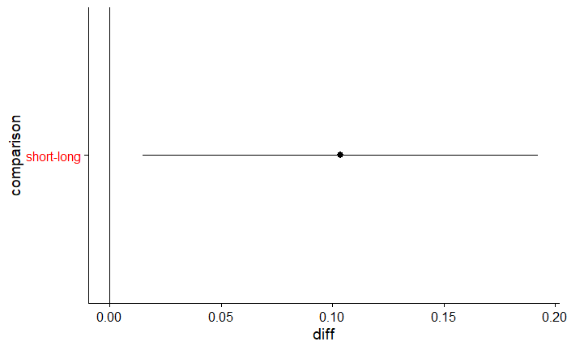

```r
plot_TukeyHSD(tuk)
```

And now wothout phage

```r
tuk <- TukeyHSD(aov(perc.spore~seed.bank,data = filter(d.perc , phage!="SPO1")))
tuk
```

```
  Tukey multiple comparisons of means
    95% family-wise confidence level

Fit: aov(formula = perc.spore ~ seed.bank, data = filter(d.perc, phage != "SPO1"))

$seed.bank
                 diff        lwr       upr     p adj
short-long -0.0231757 -0.0934761 0.0471247 0.5152847
```

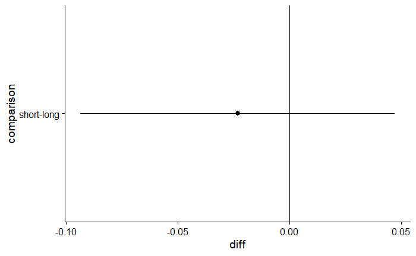

```r
plot_TukeyHSD(tuk)
```

```r
NA
NA
```

There is a seed-bank treatment effect only woth phage.